# GenEst - Command Line Walkthrough

Juniper L. Simonis

2018-12-05

This vignette walks through an example of **GenEst** at the command line and was constructed using **GenEst** version 1.1.4 on 2018-12-05.

## Installation

To obtain the most recent version of **GenEst**, download the most recent version build from [GitHub](https://github.com/ddalthorp/GenEst/tree/master/)

## Data

For this vignette, we will be using a completely generic, mock dataset provided with the **GenEst** package, which contains Searcher Efficiency (SE), Carcass Persistence (CP), Search Schedule (SS), Density Weighted Proportion (DWP), and Carcass Observation (CO) Data.

```r
data(mock)
names(mock)
```

```
#> [1] "SE"  "CP"  "SS"  "DWP" "CO"
```

## Searcher Efficiency

### Single Searcher Efficiency Model

The central function for searcher efficiency analyses is `pkm`, which, in its most basic form, conducts a singular searcher efficiency analysis (*i.e.*, a singular set of $p$ and $k$ formulae and a singular size classification of carcasses). As a first example, we will ignore the size category and use intercept-only models for both $p$ and $k$:

```r
data_SE <- mock$SE
pkModel <- pkm(formula_p = p ~ 1, formula_k = k ~ 1, data = data_SE)
```

Here, we have taken advantage of `pkm`’s default behavior of selecting observation columns (see `?pkm` for details).

```r
head(data_SE)
```

```
#>   seID Visibility HabitatType Season Size Search1 Search2 Search3 Search4
#> 1  se1          L         HT1     SF    S       1      NA      NA      NA
#> 2  se2          L         HT1     SF    S       1      NA      NA      NA
#> 3  se3          L         HT1     WS    S       0       0       0       0
#> 4  se4          L         HT1     WS    S       1      NA      NA      NA
#> 5  se5          L         HT1     WS    S       0       1      NA      NA
#> 6  se6          L         HT1     SF    S       1      NA      NA      NA
```

If we wanted to explicitly control the observations, we would use the `obsCol` argument:

```r
pkModel <- pkm(formula_p = p ~ 1, formula_k = k ~ 1, data = data_SE,
             obsCol = c("Search1", "Search2", "Search3", "Search4")
           )
```

Note that the search observations must be entered in order such that no carcasses have non-detected observations (*i.e.*, `0`) after detected observations (*i.e.*, `1`). Further, no carcasses can be detected more than once.

If successfully fit, a `pkm` model output contains a number of elements, some printed automatically:

```r
pkModel
```

```
#> $call
#> pkm0(formula_p = formula_p, formula_k = formula_k, data = data,
#>     obsCol = obsCol, kFixed = kFixed, kInit = kInit, CL = CL,
#>     quiet = quiet)
#>
#> $formula_p
#> p ~ 1
#>
#> $formula_k
#> k ~ 1
#>
#> $predictors
#> character(0)
#>
#> $AICc
#> [1] 1145
#>
#> $convergence
#> [1] 0
#>
#> $cell_pk
#>   cell   n p_median p_lower p_upper k_median k_lower k_upper
#> 1  all 480    0.568   0.532   0.604    0.599   0.543   0.653
#>
#> $CL
#> [1] 0.9
```

and others available upon request:

```r
names(pkModel)
```

```
#>  [1] "call"         "data"         "data0"        "formula_p"
#>  [5] "formula_k"    "predictors"   "predictors_p" "predictors_k"
#>  [9] "AIC"          "AICc"         "convergence"  "varbeta"
#> [13] "cellMM_p"     "cellMM_k"     "nbeta_p"      "nbeta_k"
#> [17] "betahat_p"    "betahat_k"    "cells"        "ncell"
#> [21] "cell_pk"      "CL"           "observations" "carcCells"
#> [25] "loglik"       "pOnly"
```

```r
pkModel$cells
```

```
#>   group CellNames
#> 1   all       all
```

The `plot` function has been defined for `pkm` objects, such that one can simply run

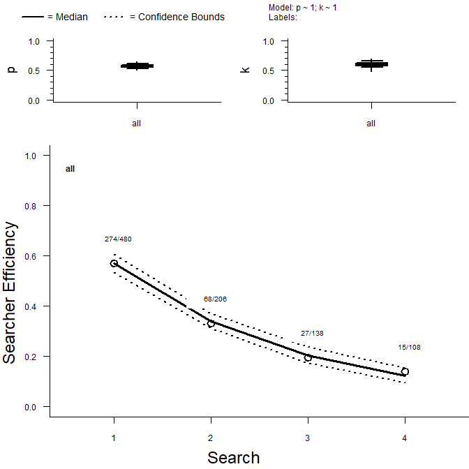

```r
plot(pkModel)
```

to visualize the model’s output.

You can generate random draws of the $p$ and $k$ parameters for each cell grouping (in `pkModel` there are no predictors, so there is one cell grouping called “all”) using the `rpk` function which, like other `r*` functions in **R** (*e.g.*, `rnorm`, `runif`) takes the number of random draws (`n`) as the first argument:

```r
rpk(n = 10, pkModel)
```

```
#> $all
#>               p         k
#>  [1,] 0.5757552 0.6111124
#>  [2,] 0.5485472 0.6191553
#>  [3,] 0.5607189 0.6520001
#>  [4,] 0.5699556 0.6269243
#>  [5,] 0.6037388 0.5905767
#>  [6,] 0.5999656 0.5577046
#>  [7,] 0.5676859 0.6584631
#>  [8,] 0.5695743 0.5578731
#>  [9,] 0.5708306 0.5635206
#> [10,] 0.5964129 0.6001012
```

You can complicate the $p$ and $k$ formulae independently

```r
pkm(formula_p = p ~ Visibility, formula_k = k ~ HabitatType, data = data_SE,
  obsCol = c("Search1", "Search2", "Search3", "Search4")
)
```

```
#> $call
#> pkm0(formula_p = formula_p, formula_k = formula_k, data = data,
#>     obsCol = obsCol, kFixed = kFixed, kInit = kInit, CL = CL,
#>     quiet = quiet)
#>
#> $formula_p
#> p ~ Visibility
#>
#> $formula_k
#> k ~ HabitatType
#>
#> $predictors
#> [1] "Visibility"  "HabitatType"
#>
#> $AICc
#> [1] 1149.67
#>
#> $convergence
#> [1] 0
#>
#> $cell_pk
#>    cell  n p_median p_lower p_upper k_median k_lower k_upper
#> 1 H.HT1 80    0.564   0.503   0.623    0.560   0.482   0.636
#> 2 L.HT1 80    0.578   0.516   0.637    0.560   0.482   0.636
#> 3 M.HT1 80    0.563   0.505   0.620    0.560   0.482   0.636
#> 4 H.HT2 80    0.564   0.503   0.623    0.631   0.557   0.700
#> 5 L.HT2 80    0.578   0.516   0.637    0.631   0.557   0.700
#> 6 M.HT2 80    0.563   0.505   0.620    0.631   0.557   0.700
#>
#> $CL
#> [1] 0.9
```

And you can fix $k$ at a nominal value between 0 and 1 (inclusive) using the `kFixed` argument

```r
pkm(formula_p = p ~ Visibility, kFixed = 0.7, data = data_SE,
  obsCol = c("Search1", "Search2", "Search3", "Search4"))
```

```
#> $call
#> pkm0(formula_p = formula_p, formula_k = formula_k, data = data,
#>     obsCol = obsCol, kFixed = kFixed, kInit = kInit, CL = CL,
#>     quiet = quiet)
#>
#> $formula_p
#> p ~ Visibility
#>
#> $formula_k
#> fixedk
#>    0.7
#>
#> $predictors
#> [1] "Visibility"
#>
#> $AICc
#> [1] 1155.63
#>
#> $convergence
#> [1] 0
#>
#> $cell_pk
#>   cell   n p_median p_lower p_upper k_median k_lower k_upper
#> 1    H 160    0.531   0.474   0.588      0.7     0.7     0.7
#> 2    L 160    0.545   0.487   0.601      0.7     0.7     0.7
#> 3    M 160    0.538   0.482   0.593      0.7     0.7     0.7
#>
#> $CL
#> [1] 0.9
```

### Set of Searcher Efficiency Models

If the arg `allCombos = TRUE` is provided, `pkm` fits a set of `pkm` models defined as all allowable models simpler than, and including, the provided model for both formulae (where “allowable” means that any interaction terms have all component terms included in the model).

Consider the following model set analysis, where visibility and habitat type are included in the $p$ formula but only habitat type is in the $k$ formula. This generates a set of 10 models:

```r
pkmModSet <- pkm(formula_p = p ~ Visibility*HabitatType,
               formula_k = k ~ HabitatType, data = data_SE,
               obsCol = c("Search1", "Search2", "Search3", "Search4"),
               allCombos = TRUE
             )
class(pkmModSet)
```

```
#> [1] "pkmSet" "list"
```

```r
names(pkmModSet)
```

```
#>  [1] "p ~ Visibility * HabitatType; k ~ HabitatType"
#>  [2] "p ~ Visibility + HabitatType; k ~ HabitatType"
#>  [3] "p ~ HabitatType; k ~ HabitatType"
#>  [4] "p ~ Visibility; k ~ HabitatType"
#>  [5] "p ~ 1; k ~ HabitatType"
#>  [6] "p ~ Visibility * HabitatType; k ~ 1"
#>  [7] "p ~ Visibility + HabitatType; k ~ 1"
#>  [8] "p ~ HabitatType; k ~ 1"
#>  [9] "p ~ Visibility; k ~ 1"
#> [10] "p ~ 1; k ~ 1"
```

The `plot` function is defined for the `pkmSet` class, and by default, creates a new plot window on command for each sub-model. If we want to only plot a specific single (or subset) of models from the full set, we can utilize the `specificModel` argument:

```r
plot(pkmModSet, specificModel = "p ~ Visibility + HabitatType; k ~ 1")
```

The resulting model outputs can be compared in an AICc table

```r
aicc(pkmModSet)
```

```
#>    p Formula                    k Formula          AICc ΔAICc
#> 10 p ~ 1                        k ~ 1           1145.00  0.00
#> 5  p ~ 1                        k ~ HabitatType 1145.70  0.70
#> 3  p ~ HabitatType              k ~ HabitatType 1146.57  1.57
#> 8  p ~ HabitatType              k ~ 1           1146.76  1.76
#> 9  p ~ Visibility               k ~ 1           1148.96  3.96
#> 4  p ~ Visibility               k ~ HabitatType 1149.67  4.67
#> 2  p ~ Visibility + HabitatType k ~ HabitatType 1150.55  5.55
#> 7  p ~ Visibility + HabitatType k ~ 1           1150.73  5.73
#> 1  p ~ Visibility * HabitatType k ~ HabitatType 1153.45  8.45
#> 6  p ~ Visibility * HabitatType k ~ 1           1153.49  8.49
```

### Multiple Sizes of Animals and Sets of Searcher Efficiency Models

```r
pkmModSetSize <- pkm(formula_p = p ~ Visibility*HabitatType,
                   formula_k = k ~ HabitatType, data = data_SE,
                   obsCol = c("Search1", "Search2", "Search3", "Search4"),
                   sizeCol = "Size", allCombos = TRUE)
class(pkmModSetSize)
```

```
#> [1] "pkmSetSize" "list"
```

The `pkmSetSize` object is a list where each element corresponds to a different unique size class, and contains the associated `pkmSet`object, which itself is a list of `pkm` outputs:

```r
names(pkmModSetSize)
```

```
#> [1] "L"  "M"  "S"  "XL"
```

```r
names(pkmModSetSize[[1]])
```

```
#>  [1] "p ~ Visibility * HabitatType; k ~ HabitatType"
#>  [2] "p ~ Visibility + HabitatType; k ~ HabitatType"
#>  [3] "p ~ HabitatType; k ~ HabitatType"
#>  [4] "p ~ Visibility; k ~ HabitatType"
#>  [5] "p ~ 1; k ~ HabitatType"
#>  [6] "p ~ Visibility * HabitatType; k ~ 1"
#>  [7] "p ~ Visibility + HabitatType; k ~ 1"
#>  [8] "p ~ HabitatType; k ~ 1"
#>  [9] "p ~ Visibility; k ~ 1"
#> [10] "p ~ 1; k ~ 1"
```

## Carcass Persistence

### Single Carcass Persistence Model

The central function for carcass persistence analyses is `cpm`, which, in its simplest form, conducts a singular carcass persistence analysis (*i.e.*, a singular set of $l$ and $s$ formulae and a singular size classification of carcasses). Note that we use $l$ and $s$ to reference $location$ and $scale$ as the parameters for survival models, following `survreg`, however we also provide an alternative parameterization (using parameters $a$ and $b$, referred to as “`ab`” or “ppersist”). As a first example, we will ignore the size category, use intercept-only models for both $l$ and $s$, and use the Weibull distribution:

```r
data_CP <- mock$CP
cpModel <- cpm(formula_l = l ~ 1, formula_s = s ~ 1, data = data_CP,
             left = "LastPresentDecimalDays",
             right = "FirstAbsentDecimalDays", dist = "weibull"
           )
```

If successfully fit, a `cpm` model output contains a number of elements, some printed automatically:

```r
cpModel
```

```
#> $call
#> cpm0(formula_l = formula_l, formula_s = formula_s, data = data,
#>     left = left, right = right, dist = dist, CL = CL, quiet = quiet)
#>
#> $formula_l
#> l ~ 1
#>
#> $formula_s
#> s ~ 1
#>
#> $distribution
#> [1] "weibull"
#>
#> $predictors
#> character(0)
#>
#> $AICc
#> [1] 2102.11
#>
#> $convergence
#> [1] 0
#>
#> $cell_ls
#>   cell   n l_median l_lower l_upper s_median s_lower s_upper
#> 1  all 480    2.671   2.592   2.749    0.966   0.901   1.037
#>
#> $cell_ab
#>   cell   n pda_median pda_lower pda_upper pdb_median pdb_lower pdb_upper
#> 1  all 480      1.035      1.11     0.964     14.454    13.356    15.627
#>
#> $CL
#> [1] 0.9
#>
#> $cell_desc
#>   cell medianCP        r1        r3        r7       r14       r28
#> 1  all  10.1437 0.9696732 0.9094574 0.8003887 0.6463498 0.4427757
```

and others available upon request:

```r
names(cpModel)
```

```
#>  [1] "call"         "data"         "formula_l"    "formula_s"
#>  [5] "distribution" "predictors"   "predictors_l" "predictors_s"
#>  [9] "AIC"          "AICc"         "convergence"  "varbeta"
#> [13] "cellMM_l"     "cellMM_s"     "nbeta_l"      "nbeta_s"
#> [17] "betahat_l"    "betahat_s"    "cells"        "ncell"
#> [21] "cell_ls"      "cell_ab"      "CL"           "observations"
#> [25] "carcCells"    "loglik"       "cell_desc"
```

```r
cpModel$cells
```

```
#>   group CellNames
#> 1   all       all
```

The `plot` function has been defined for `cpm` objects, such that one can simply run

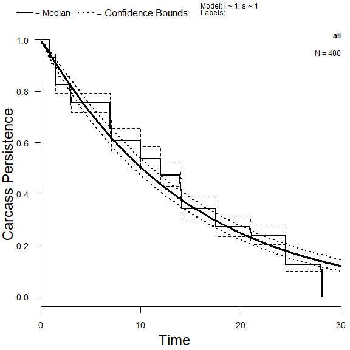

```r
plot(cpModel)
```

to visualize the model’s output.

You can generate random draws of the $l$ and $s$ (or $a$ and $b$) parameters for each cell grouping (in `cpModel` there are no predictors, so there is one cell grouping called “all”) using the `rcp` function which, like other `r*` functions in **R** (*e.g.*, `rnorm`) takes the number of random draws (`n`) as the first argument:

```r
rcp(n = 10, cpModel)
```

```
#> $all
#>              l         s
#>  [1,] 2.667938 1.0338505
#>  [2,] 2.669906 0.9432373
#>  [3,] 2.624413 0.9426336
#>  [4,] 2.725055 0.9765017
#>  [5,] 2.678181 0.9136847
#>  [6,] 2.614384 0.9599418
#>  [7,] 2.818511 0.9516491
#>  [8,] 2.637658 0.9607057
#>  [9,] 2.725777 0.8937671
#> [10,] 2.696035 0.9226017
```

```r
rcp(n = 10, cpModel, type = "ppersist")
```

```
#> $all
#>             pda      pdb
#>  [1,] 1.0299455 14.22095
#>  [2,] 1.0631111 15.61477
#>  [3,] 1.0442141 14.56081
#>  [4,] 0.9707085 13.79265
#>  [5,] 1.0665873 15.08344
#>  [6,] 1.0414856 14.00758
#>  [7,] 1.0420301 14.15536
#>  [8,] 1.0371340 13.97719
#>  [9,] 1.0554227 15.74361
#> [10,] 1.0344494 13.84287
```

You can complicate the $l$ and $s$ formulae independently

```r
cpm(formula_l = l ~ Visibility * GroundCover, formula_s = s ~ 1, data = data_CP,
  left = "LastPresentDecimalDays", right = "FirstAbsentDecimalDays",
  dist = "weibull"
)
```

```
#> $call
#> cpm0(formula_l = formula_l, formula_s = formula_s, data = data,
#>     left = left, right = right, dist = dist, CL = CL, quiet = quiet)
#>
#> $formula_l
#> l ~ Visibility * GroundCover
#>
#> $formula_s
#> s ~ 1
#>
#> $distribution
#> [1] "weibull"
#>
#> $predictors
#> [1] "Visibility"  "GroundCover"
#>
#> $AICc
#> [1] 2109.36
#>
#> $convergence
#> [1] 0
#>
#> $cell_ls
#>   cell  n l_median l_lower l_upper s_median s_lower s_upper
#> 1  H.A 80    2.647   2.457   2.836    0.964   0.898   1.034
#> 2  L.A 80    2.618   2.427   2.809    0.964   0.898   1.034
#> 3  M.A 80    2.536   2.350   2.722    0.964   0.898   1.034
#> 4  H.B 80    2.789   2.597   2.981    0.964   0.898   1.034
#> 5  L.B 80    2.710   2.521   2.900    0.964   0.898   1.034
#> 6  M.B 80    2.716   2.527   2.905    0.964   0.898   1.034
#>
#> $cell_ab
#>   cell  n pda_median pda_lower pda_upper pdb_median pdb_lower pdb_upper
#> 1  H.A 80      1.037     1.114     0.967     14.112    11.670    17.047
#> 2  L.A 80      1.037     1.114     0.967     13.708    11.325    16.593
#> 3  M.A 80      1.037     1.114     0.967     12.629    10.486    15.211
#> 4  H.B 80      1.037     1.114     0.967     16.265    13.423    19.708
#> 5  L.B 80      1.037     1.114     0.967     15.029    12.441    18.174
#> 6  M.B 80      1.037     1.114     0.967     15.120    12.516    18.265
#>
#> $CL
#> [1] 0.9
#>
#> $cell_desc
#>   cell  medianCP        r1        r3        r7       r14       r28
#> 1  H.A  9.910449 0.9691191 0.9076888 0.7965531 0.6402617 0.4355206
#> 2  L.A  9.626732 0.9681953 0.9050529 0.7912752 0.6323916 0.4266794
#> 3  M.A  8.868981 0.9654396 0.8972323 0.7757825 0.6096922 0.4019134
#> 4  H.B 11.422439 0.9732702 0.9196215 0.8208024 0.6773283 0.4789728
#> 5  L.B 10.554432 0.9710322 0.9131703 0.8076196 0.6569919 0.4547593
#> 6  M.B 10.618339 0.9712095 0.9136797 0.8086542 0.6585719 0.4566077
```

Given that the exponential only has one parameter ($l$, location), a model for scale (`formula_s`) is not required:

```r
cpModExp <- cpm(formula_l = l ~ Visibility * GroundCover, data = data_CP,
              left = "LastPresentDecimalDays",
              right = "FirstAbsentDecimalDays", dist = "exponential"
            )
```

### Set of Carcass Persistence Models

If the arg `allCombos = TRUE` is provided, `cpm` fits a set of `cpm` models defined as all allowable models simpler than, and including, the provided model formulae (where “allowable” means that any interaction terms have all component terms included in the model).

In addition, `cpm` with `allCombos` can include any subset of the four base distributions (exponential, weibull, lognormal, loglogistic) and crosses them with the predictor models.

Consider the following model set analysis, where `Visibility` and `Season` are included in the $l$ formula but only `Visibility` is in the $s$ formula, and only the exponential and lognormal distributions are included. This generates a set of 15 models:

```r
cpmModSet <- cpm(formula_l = l ~ Visibility * Season,
               formula_s = s ~ Visibility, data = data_CP,
               left = "LastPresentDecimalDays",
               right = "FirstAbsentDecimalDays",
               dist = c("exponential", "lognormal"), allCombos = TRUE
             )
class(cpmModSet)
```

```
#> [1] "cpmSet" "list"
```

```r
names(cpmModSet)
```

```
#>  [1] "dist: exponential; l ~ Visibility * Season; NULL"
#>  [2] "dist: exponential; l ~ Visibility + Season; NULL"
#>  [3] "dist: exponential; l ~ Season; NULL"
#>  [4] "dist: exponential; l ~ Visibility; NULL"
#>  [5] "dist: exponential; l ~ 1; NULL"
#>  [6] "dist: lognormal; l ~ Visibility * Season; s ~ Visibility"
#>  [7] "dist: lognormal; l ~ Visibility + Season; s ~ Visibility"
#>  [8] "dist: lognormal; l ~ Season; s ~ Visibility"
#>  [9] "dist: lognormal; l ~ Visibility; s ~ Visibility"
#> [10] "dist: lognormal; l ~ 1; s ~ Visibility"
#> [11] "dist: lognormal; l ~ Visibility * Season; s ~ 1"
#> [12] "dist: lognormal; l ~ Visibility + Season; s ~ 1"
#> [13] "dist: lognormal; l ~ Season; s ~ 1"
#> [14] "dist: lognormal; l ~ Visibility; s ~ 1"
#> [15] "dist: lognormal; l ~ 1; s ~ 1"
```

The resulting model outputs can be compared in an AICc table

```r
aicc(cpmModSet)
```

```
#>    Distribution Location Formula        Scale Formula     AICc ΔAICc
#> 5  exponential  l ~ 1                   NULL           2100.72  0.00
#> 3  exponential  l ~ Season              NULL           2101.08  0.36
#> 4  exponential  l ~ Visibility          NULL           2104.16  3.44
#> 2  exponential  l ~ Visibility + Season NULL           2104.48  3.76
#> 1  exponential  l ~ Visibility * Season NULL           2108.17  7.45
#> 15 lognormal    l ~ 1                   s ~ 1          2159.24 58.52
#> 13 lognormal    l ~ Season              s ~ 1          2160.78 60.06
#> 10 lognormal    l ~ 1                   s ~ Visibility 2162.15 61.43
#> 14 lognormal    l ~ Visibility          s ~ 1          2163.19 62.47
#> 8  lognormal    l ~ Season              s ~ Visibility 2163.67 62.95
#> 12 lognormal    l ~ Visibility + Season s ~ 1          2164.74 64.02
#> 9  lognormal    l ~ Visibility          s ~ Visibility 2166.13 65.41
#> 11 lognormal    l ~ Visibility * Season s ~ 1          2166.91 66.19
#> 7  lognormal    l ~ Visibility + Season s ~ Visibility 2167.66 66.94
#> 6  lognormal    l ~ Visibility * Season s ~ Visibility 2169.79 69.07
```

The `plot` function is defined for the `cpmSet` class, and by default, creates a new plot window on command for each sub-model. If we want to only plot a specific single (or subset) of models from the full set, we can utilize the `specificModel` argument:

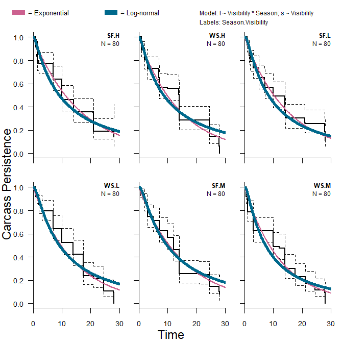

```r
plot(cpmModSet,
  specificModel = "dist: lognormal; l ~ Visibility * Season; s ~ Visibility"
)
```

### Multiple Sizes of Animals and Sets of Carcass Persistence Models

Often, carcasses are grouped in multiple size classes, and we are interested in analyzing a set of models separately for each size class. To do so, we furnish `cpm` with `sizeCol`, which is the name of the column in `data_CP` that gives the size classes of the carcasses. If, in addition, `allCombos = TRUE`, then `cpm` returns a `cpmSet` for each unique size class in the column identified by the `sizeCol` argument:

```r
cpmModSetSize <- cpm(formula_l = l ~ Visibility * Season,
                   formula_s = s ~ Visibility, data = data_CP,
                   left = "LastPresentDecimalDays",
                   right = "FirstAbsentDecimalDays",
                   dist = c("exponential", "lognormal"),
                   sizeCol = "Size", allCombos = TRUE)
class(cpmModSetSize)
```

```
#> [1] "cpmSetSize" "list"
```

The `cpmSetSize` object is a list where each element corresponds to a different unique size class, and contains the associated `cpmSet`o bject, which itself is a list of `cpm` outputs:

```r
names(cpmModSetSize)
```

```
#> [1] "L"  "M"  "S"  "XL"
```

```r
names(cpmModSetSize[[1]])
```

```
#>  [1] "dist: exponential; l ~ Visibility * Season; NULL"
#>  [2] "dist: exponential; l ~ Visibility + Season; NULL"
#>  [3] "dist: exponential; l ~ Season; NULL"
#>  [4] "dist: exponential; l ~ Visibility; NULL"
#>  [5] "dist: exponential; l ~ 1; NULL"
#>  [6] "dist: lognormal; l ~ Visibility * Season; s ~ Visibility"
#>  [7] "dist: lognormal; l ~ Visibility + Season; s ~ Visibility"
#>  [8] "dist: lognormal; l ~ Season; s ~ Visibility"
#>  [9] "dist: lognormal; l ~ Visibility; s ~ Visibility"
#> [10] "dist: lognormal; l ~ 1; s ~ Visibility"
#> [11] "dist: lognormal; l ~ Visibility * Season; s ~ 1"
#> [12] "dist: lognormal; l ~ Visibility + Season; s ~ 1"
#> [13] "dist: lognormal; l ~ Season; s ~ 1"
#> [14] "dist: lognormal; l ~ Visibility; s ~ 1"
#> [15] "dist: lognormal; l ~ 1; s ~ 1"
```

```r
class(cpmModSetSize[[1]])
```

```
#> [1] "cpmSet" "list"
```

## Generic Detection Probability

For the purposes of mortality estimation, we calculate carcass-specific detection probabilities (see below), which may be difficult to generalize, given the specific history of each observed carcass. Thus, we also provide a simple means to calculate generic detection probabilities that are cell-specific, rather than carcass-specific.

For any estimation of detection probability ($\hat{g}$), we need to have singular SE and CP models to use for each of the size classes. Here, we use the best-fit of the models for each size class:

```r
pkMods <- c("S" = "p ~ 1; k ~ 1", "L" = "p ~ 1; k ~ 1",
            "M" = "p ~ 1; k ~ 1", "XL" = "p ~ 1; k ~ HabitatType"
          )
cpMods <- c("S" = "dist: exponential; l ~ Season; NULL",
            "L" = "dist: exponential; l ~ 1; NULL",
            "M" = "dist: exponential; l ~ 1; NULL",
            "XL" = "dist: exponential; l ~ 1; NULL"
          )
```

The `estgGenericSize` function produces `n` random draws of generic (i.e., cell-specific, not carcass-sepecific) detection probabilities for each of the possible carcass cell combinations across the selected SE and CP models across the size classes. `estgGeneric` is a single-size-class version of function and `estgGenericSize` actually loops over `estgGeneric`. The generic $\hat{g}$ is estimated according to a particular search schedule. When we pass `averageSS` a full `data_SS` table like we have here, it will assume that columns filled exclusively with 0s and 1s represent search schedules for units and will create the average search schedule across the units.

```r
data_SS <- mock$SS
avgSS <- averageSS(data_SS)

gsGeneric <- estgGenericSize(nsim = 1000, days = avgSS,
               modelSetSize_SE = pkmModSetSize,
               modelSetSize_CP = cpmModSetSize,
               modelSizeSelections_SE = pkMods,
               modelSizeSelections_CP = cpMods
             )
```

The output from `estgGeneric` can be simply summarized

```r
summary(gsGeneric)
```

```
#> $L
#>   Group    5%   25%  50%   75%   95%
#> 1   all 0.376 0.409 0.43 0.452 0.486
#>
#> $M
#>   Group    5%   25%   50%   75%   95%
#> 1   all 0.351 0.386 0.406 0.429 0.462
#>
#> $S
#>   Season    5%   25%   50%   75%   95%
#> 1     SF 0.359 0.398 0.426 0.452 0.493
#> 2     WS 0.298 0.335 0.358 0.383 0.419
#>
#> $XL
#>   HabitatType    5%   25%   50%   75%   95%
#> 1         HT1 0.315 0.346 0.369 0.393 0.426
#> 2         HT2 0.329 0.359 0.383 0.407 0.438
```

or plotted.

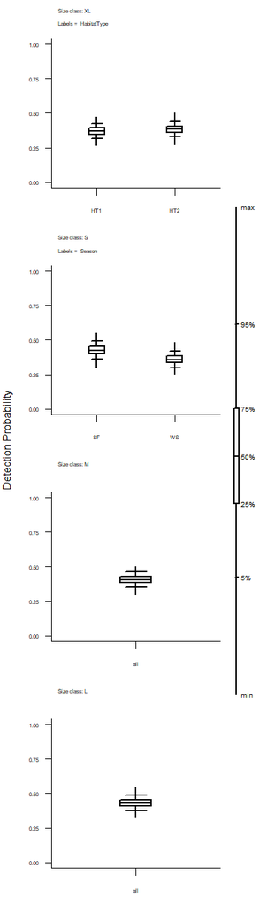

```r
plot(gsGeneric)
```

## Mortality Estimation

When estimating mortality, detection probability is determined for individual carcasses based on the dates when they are observed, size class values, associated covariates, the searcher efficiency and carcass persistence models, and the search schedule. The carcass-specific detection probabilities (as opposed to the generic/cell-specific detection probabilities above) are therefore calculated before estimating the total mortality. Although it is possible to estimate these detection probabilities separately, they are best interpreted in the context of a full mortality estimation.

The `estM` function is the general wrapper function for estimating `M`, whether for a single size class or multiple size classes. Prior to estimation, we need to reduce the model-set-size complexed to just a single chosen model per size class, corresponding to the `pkMods` and `cpMods` vectors given above. To reduce the model set complexity, we can use the `trimSetSize` function:

```r
pkmModSize <- trimSetSize(pkmModSetSize, pkMods)
cpmModSize <- trimSetSize(cpmModSetSize, cpMods)
```

In addition to the models and search schedule data, `estM` requires density-weighted proportion (DWP) and carcass observation (CO) data. If more than one size class is represented in the data, a required input is also the column names associated with the DWP value for each size class (argument `DWPCol` in `estM`):

```r
data_CO <- mock$CO
data_DWP <- mock$DWP
head(data_DWP)
```

```
#>    Unit    S    M    L   XL
#> 1 Unit1 0.70 0.70 0.60 0.60
#> 2 Unit2 0.70 0.70 0.60 0.60
#> 3 Unit3 0.56 0.56 0.48 0.48
#> 4 Unit4 0.56 0.56 0.48 0.48
#> 5 Unit5 0.70 0.70 0.60 0.60
```

```r
DWPcolnames <- names(pkmModSize)

eM <- estM(data_CO = data_CO, data_SS = data_SS, data_DWP = data_DWP,
        frac = 1, model_SE = pkmModSize, model_CP = cpmModSize,
        seed_SE = NULL, seed_CP = NULL, seed_g = NULL, seed_M = NULL,
        unitCol = "Unit", COdate = "DateFound",
        SSdate = "DateSearched", sizeCol = "Size", nsim = 1000)
```

`estM` returns an object that contains the random draws of `pkm` and `cpm` parameters (named `pk` and `ab`, respectively) and the estimated carcass-level detection parameters (`g`), arrival intervals (`Aj`), and associated total mortality (`Mhat`) values for each simulation. These `Mhat` values should be considered in combination, and can be summarized and plotted simply:

```r
summary(eM)
```

```
#>  median      5%     95%
#> 1811.09 1647.66 1982.47
```

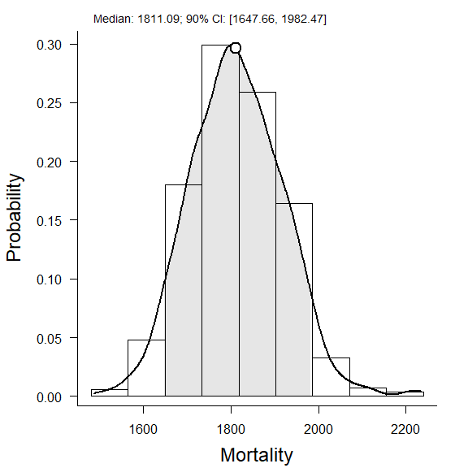

```r
plot(eM)
```

### Splitting Mortality Estimations

It is possible to split the resulting mortality estimation into components that are denoted according to covariates in either the search schedule or carcass observation data sets.

First, a temporal split:

```r
M_season <- calcSplits(M = eM, split_SS = "Construction",
                 split_CO = NULL, data_SS = data_SS, data_CO = data_CO
             )
summary(M_season)
```

```
#>               X        5%       25%       50%       75%       95%
#> Before 161.5108  591.5065  642.3386  677.2794  718.4219  773.4741
#> After  264.4892 1011.9878 1084.5125 1130.8355 1180.4037 1258.7803
#> attr(,"class")
#> [1] "splitSummary"
#> attr(,"CL")
#> [1] 0.9
#> attr(,"vars")
#> [1] "Construction"
#> attr(,"type")
#> [1] "SS"
#> attr(,"times")
#> [1]   0 127 349
```

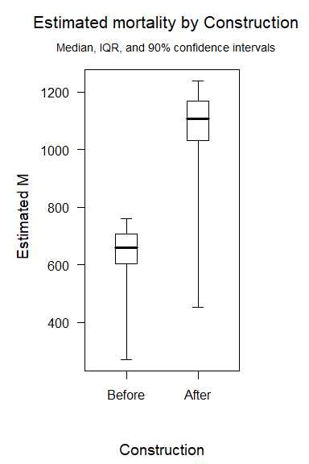

```r
plot(M_season)
```

Next, a carcass split:

```r
M_class <- calcSplits(M = eM, split_SS = NULL,
             split_CO = "Split", data_SS = data_SS, data_CO = data_CO
           )
summary(M_class)
```

```
#>      X       5%      25%      50%      75%       95%
#> C1 196 733.2844 787.6625 826.8950  869.513  932.6185
#> C2 230 876.6440 936.8937 984.2261 1027.658 1100.5501
#> attr(,"class")
#> [1] "splitSummary"
#> attr(,"CL")
#> [1] 0.9
#> attr(,"vars")
#> [1] "Split"
#> attr(,"type")
#> [1] "CO"
```

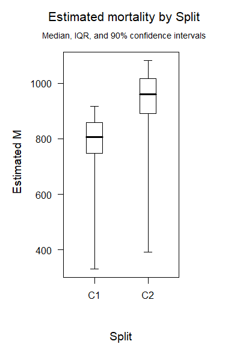

```r
plot(M_class)
```

And finally, if two splits are included, the mortality estimation is expanded fully factorially:

```r
M_SbyC <- calcSplits(M = eM, split_SS = "Construction",
            split_CO = "Split", data_SS = data_SS, data_CO = data_CO
          )
summary(M_SbyC)
```

```
#> $C1
#>                X       5%      25%      50%      75%      95%
#> Before  80.24521 281.4390 311.0720 332.6060 358.0864 393.4851
#> After  115.75479 422.1198 462.7733 492.4431 523.4280 571.1372
#>
#> $C2
#>                X       5%      25%      50%      75%      95%
#> Before  81.26557 288.3014 318.5784 344.4808 369.4505 409.4684
#> After  148.73443 558.6102 603.9752 638.6064 671.6607 720.6139
#>
#> attr(,"class")
#> [1] "splitSummary"
#> attr(,"CL")
#> [1] 0.9
#> attr(,"vars")
#> [1] "Construction" "Split"
#> attr(,"type")
#> [1] "SS" "CO"
#> attr(,"times")
#> [1]   0 127 349
```

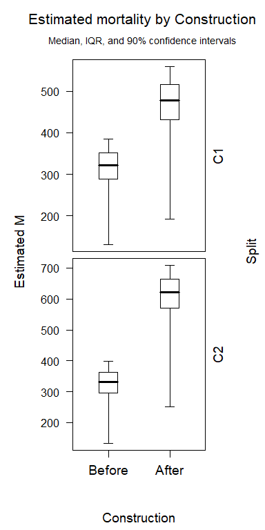

```r
plot(M_SbyC)
```